# The Real Problem

Recognizing multi-digit numbers in photographs captured at street level is an important component of modern-day map making. A classic example of a corpus of such street level photographs is Google’s Street View imagery comprised of hundreds of millions of geo-located 360 degree panoramic images. The ability to automatically transcribe an address number from a geo-located patch of pixels and associate the transcribed number with a known street address helps pinpoint, with a high degree of accuracy, the location of the building it represents. More broadly, recognizing numbers in photographs is a problem of interest to the optical character recognition community. While OCR on constrained domains like document processing is well studied, arbitrary multi-character text recognition in photographs is still highly challenging. This difficulty arises due to the wide variability in the visual appearance of text in the wild on account of a large range of fonts, colors, styles, orientations, and character arrangements. The recognition problem is further complicated by environmental factors such as lighting, shadows, specularities, and occlusions as well as by image acquisition factors such as resolution, motion, and focus blurs. In this project we will use dataset with images centred around a single digit (many of the images do contain some distractors at the sides). Although we are taking a sample of the data which is simpler, it is more complex than MNIST because of the distractors.

# The Street View House Numbers (SVHN) Dataset

SVHN is a real-world image dataset for developing machine learning and object recognition algorithms with minimal requirement on data formatting but comes from a significantly harder, unsolved, real world problem (recognizing digits and numbers in natural scene images). SVHN is obtained from house numbers in Google Street View images.

# Link to the dataset:

https://drive.google.com/file/d/1L2-WXzguhUsCArrFUc8EEkXcj33pahoS/view?usp=sharing

# Acknowledgement for the datasets.

Yuval Netzer, Tao Wang, Adam Coates, Alessandro Bissacco, Bo Wu, Andrew Y. Ng Reading Digits in Natural Images with Unsupervised Feature Learning NIPS Workshop on Deep Learning and Unsupervised Feature Learning 2011. PDF http://ufldl.stanford.edu/housenumbers as the URL for this site when necessary

The objective of the project is to learn how to implement a simple image classification pipeline based on a deep neural network. The goals of this project are as follows:  
● Understand the basic Image Classification pipeline and the data-driven approach (train/predict stages)  
● Data fetching and understand the train/val/test splits. (5 points) ● Implement and apply a deep neural network classifier including (feedforward neural network, RELU, activations) (10 points)  
● Understand and be able to implement (vectorized) backpropagation (cost stochastic gradient descent, cross entropy loss, cost functions) (10 points)  
● Implement batch normalization for training the neural network (5 points)  
● Print the classification accuracy metrics (5 points)

## EDA

### importing libraries

```python
import numpy as np #for numpy
from tensorflow.keras.models import Sequential #for sequential model
from tensorflow.keras.layers import Dense, Dropout, BatchNormalization,Flatten,LeakyReLU,Activation #for various keras layers
from sklearn.metrics import accuracy_score, confusion_matrix, precision_score, recall_score, classification_report # for evaluation matrices
from sklearn.metrics import f1_score #for f1 score
import matplotlib.pyplot as plt #for matplotlib
from tensorflow.keras import optimizers #for optimizers in keras
from keras.regularizers import l1,l2,l1_l2 #for regularizers
from keras.callbacks import LearningRateScheduler #for learning rate scheduling
from keras.callbacks import History #for history callback
import h5py #for h5 file
import keras #import keras
import math #import math
from sklearn.model_selection import GridSearchCV,RandomizedSearchCV #import crossvalidation
from keras.wrappers.scikit_learn import KerasClassifier #import kerasclassifier
import tensorflow as tf # for tensorflow
```

### Load the X_train, X_test, Y_train, Y_test, X_val and Y_val datasets from the h5py file

```python
data = h5py.File('SVHN_single_grey1.h5', 'r') #read h5 file

X_test = data['X_test'][:] #Xtest data
X_train = data['X_train'][:]#XTrain data
X_val = data['X_val'][:]#XVal data
y_test = data['y_test'][:].flatten()#ytest data
y_train = data['y_train'][:].flatten()#ytrain data
y_val = data['y_val'][:].flatten()#yVal data

data.close()#close file
```

### Flatten the images for Keras

- As the images have 32x32 shape,32*32=1024. Reshaping to 1024 and flattening the dataset

```python
#flatten
X_test = X_test.reshape(X_test.shape[0],1024) #reshape
X_train = X_train.reshape(X_train.shape[0],1024) #reshape
X_val = X_val.reshape(X_val.shape[0],1024) #reshape
```

### Normalize the inputs for X_train, X_test and X_val

- The images can store values in the range of 0-255. Normalizing using maximum value i.e. 255

```python
# normalize inputs
X_train = X_train/255.0 # normalize
X_test = X_test/255.0 # normalize
X_val = X_val/255.0 # normalize
```

### Convert the class matrices Y_train, Y_test and Y_val into one hot vectors

```python
#onehot encoding using keras
y_train_one = keras.utils.to_categorical(y_train) #onehot encoding
y_val_one = keras.utils.to_categorical(y_val) #onehot encoding
y_test_one = keras.utils.to_categorical(y_test) #onehot encoding
```

### Print the train, test and val shapes

```python
print('\033[1m''X_train Shape',X_train.shape)#print shapes
print('\033[1m''X_test Shape',X_test.shape)#print shapes
print('\033[1m''X_val Shape',X_val.shape)#print shapes

print('\033[1m''y_train Shape',y_train_one.shape)#print shapes
print('\033[1m''y_test Shape',y_test_one.shape)#print shapes
print('\033[1m''y_val Shape',y_val_one.shape)#print shapes
```

```
X_train Shape (42000, 1024)
X_test Shape (18000, 1024)
X_val Shape (60000, 1024)
y_train Shape (42000, 10)
y_test Shape (18000, 10)
y_val Shape (60000, 10)
```

### Visualize the first 10 images in X_train and the corresponding Y_train labels

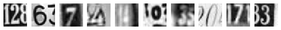

```
label for each of the above image: [2 6 7 4 4 0 3 0 7 3]
```

```python
#visualize first 10 images using imshow

import matplotlib.pyplot as plt #import pyplot
plt.figure(figsize=(10, 1)) #set figure size
for i in range(10): #select first 10 images
    plt.subplot(1, 10, i+1) #create subplot
    plt.imshow(X_train[i].reshape(32, 32), cmap="gray") #display image
    plt.axis('off')
plt.show() #display all images
print('label for each of the above image: %s' % (y_train[0:10])) #labels of images
```

## Model Building

### Create a Sequential model in Keras with input layer with the correct input shape, Hidden Layers, Output Layers and the activation functions

- Following is a sequential model with 1 input layer, 1 output layer and 5 hidden layers.
- The network is dense i.e. fully connected and each layer has different number of neurons.
- BatchNormalization is added after each layer before activation.
- LeakyReLU and softmax activations are used in the network.
- Dropout is added randomely after some layers.
- 'he_normal' kernel initializer is used.

```python
def build_basic_model():

    model = Sequential() #sequential network
    model.add(Dense(1024, input_shape=(1024,),kernel_initializer='he_normal'))#dense layer eith 1024 neurons
    model.add(BatchNormalization())#batch normalization
    model.add(LeakyReLU(alpha=0.1))#leakyrelu activation


    model.add(Dense(512,kernel_initializer='he_normal'))
    model.add(BatchNormalization())#batch normalization
    model.add(LeakyReLU(alpha=0.1))#leakyrelu activation

    model.add(Dense(256, kernel_initializer='he_normal'))
    model.add(BatchNormalization())#batch normalization
    model.add(LeakyReLU(alpha=0.1))#leakyrelu activation
    model.add(Dropout(0.3))

    model.add(Dense(128,kernel_initializer='he_normal'))
    model.add(BatchNormalization())#batch normalization
    model.add(LeakyReLU(alpha=0.3))#leakyrelu activation


    model.add(Dense(64,kernel_initializer='he_normal'))
    model.add(BatchNormalization())#batch normalization
    model.add(LeakyReLU(alpha=0.3))#leakyrelu activation
    model.add(Dropout(0.3))#dropout

    model.add(Dense(32,kernel_initializer='he_normal'))
    model.add(BatchNormalization())#batch normalization
    model.add(LeakyReLU(alpha=0.3))#leakyrelu activation
    model.add(Dropout(0.3))#dropout

    model.add(Dense(10, activation='softmax'))    #dense layer with softmax activation

    return model
```

### Define the optimizer to be used in this model

- SGD is used with default learning rate of 0.01

```python
optimizer = optimizers.SGD() #SGD
```

### Compile the model with the corresponding Loss and metrics to monitor

- Model is compiled with 'categorical_crossentropy' metrics as the output is multiclass.
- Accuracy metrics will be used for evaluation of the network.

```python
model = build_basic_model() #build model
model.compile(loss='categorical_crossentropy', optimizer=optimizer,  metrics=['accuracy'])#compile model
```

### Fit the model and use model.evaluate() to return the score

- The fit method autmoatically implements forward and backward propagation.
- As we have validation data, it is passed as validation data to the fit method.
- batchsize and epochs are chosen randomly, but best suitable values will be searched using cross validation further in the project.

```python
model.fit(X_train, y_train_one , batch_size = 200, epochs = 50, validation_data=(X_val,y_val_one),verbose=0) #fit model
```

```
<tensorflow.python.keras.callbacks.History at 0x1b1c8546708>
```

```python
results = model.evaluate(X_test, y_test_one,verbose=2)#evaluate model
```

```
18000/1 - 1s - loss: 0.4115 - accuracy: 0.8164
```

#### Observations from first iteration of the network

- After each epoch the validation loss kept decreasing and network kept optimizing itself using sgd.
- The validation data helped the network to improve accuracy and reduce loss resulting in reduced overfitting.
- The loss of 0.4115 and accuracy of 0.8164 is recorded on test data.
- The loss can be reduced and accuracy can be improved.

### Disable Regularization by setting appropriate value for Lambda and check the loss of the NN

- For regularization, kernel_regularizer parameter is used with value of 0. to disable regularization of the network.
- Also, the optimizer is changed to adam with learning rate of 0.0001 for improved gradient handeling.
- Dropout has beed added to reduce overfitting.

```python
def build_model_regulariztion(lam):
    model = Sequential() #sequential network
    model.add(Dense(1024, input_shape=(1024,),kernel_regularizer=l2(lam)))#dense layer with 1024 neurons
    model.add(BatchNormalization())#batch normalization
    model.add(LeakyReLU(alpha=0.1))#leaky relu
    model.add(Dropout(0.1))#dropout


    model.add(Dense(512,kernel_initializer= 'he_normal',kernel_regularizer=l2(lam)))#dense layer
    model.add(BatchNormalization())#batch normalization
    model.add(LeakyReLU(alpha=0.1))#leaky relu
    model.add(Dropout(0.1))#dropout


    model.add(Dense(256,kernel_initializer='he_normal',kernel_regularizer=l2(lam)))#dense layer
    model.add(BatchNormalization())#batch normalization
    model.add(LeakyReLU(alpha=0.1))#leaky relu
    model.add(Dropout(0.1))#dropout


    model.add(Dense(128,kernel_initializer='he_normal',kernel_regularizer=l2(lam)))#dense layer
    model.add(BatchNormalization())#batch normalization
    model.add(LeakyReLU(alpha=0.1))#leaky relu
    model.add(Dropout(0.3))#dropout

    model.add(Dense(64,kernel_initializer='he_normal',kernel_regularizer=l2(lam)))#dense layer
    model.add(BatchNormalization())#batch normalization
    model.add(LeakyReLU(alpha=0.1))#leaky relu
    model.add(Dropout(0.1))#dropout

    model.add(Dense(32,kernel_initializer='he_normal',kernel_regularizer=l2(lam)))#dense layer
    model.add(BatchNormalization())#batch normalization
    model.add(LeakyReLU(alpha=0.1))#leaky relu
    model.add(Dropout(0.2))#dropout


    model.add(Dense(10, activation='softmax')) #dense layer with softmax activation
    return model
```

```python
lr = 0.0001   #learning rate
optimizer = optimizers.Adam(lr=lr) #adam optimizer
model=build_model_regulariztion(0.) #model with disabled regularization
model.compile(loss='categorical_crossentropy', optimizer=optimizer,  metrics=['accuracy']) #compile model
model.fit(X_train,y_train_one , batch_size = 500, epochs = 100, validation_data=(X_val,y_val_one),verbose=0) #fit model on train and validation data
```

```
<tensorflow.python.keras.callbacks.History at 0x1b313c2fdc8>
```

```python
results = model.evaluate(X_test, y_test_one,verbose=2)#evaluate network on test data
```

```
18000/1 - 1s - loss: 0.6557 - accuracy: 0.7892
```

```python
model_H=model.fit(X_train,y_train_one , batch_size = 500, epochs = 100, validation_data=(X_val,y_val_one),verbose=0) #create history object
```

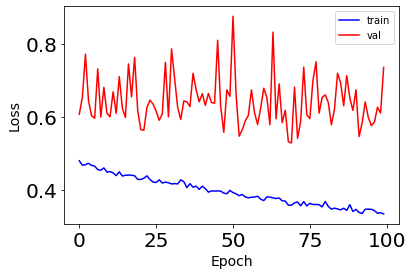

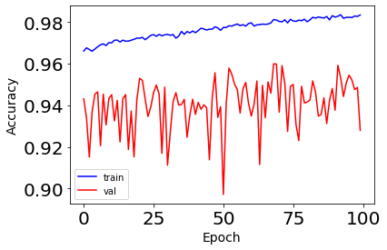

```python
# Plot the loss function
fig, ax = plt.subplots(1, 1, figsize=(6,4))
ax.plot(np.sqrt(model_H.history['loss']), 'b', label='train')
ax.plot(np.sqrt(model_H.history['val_loss']), 'r' ,label='val')
ax.set_xlabel(r'Epoch', fontsize=14)
ax.set_ylabel(r'Loss', fontsize=14)
ax.legend()
ax.tick_params(labelsize=20)

# Plot the accuracy
fig, ax = plt.subplots(1, 1, figsize=(6,4))
ax.plot(np.sqrt(model_H.history['accuracy']), 'b', label='train')
ax.plot(np.sqrt(model_H.history['val_accuracy']), 'r' ,label='val')
ax.set_xlabel(r'Epoch', fontsize=14)
ax.set_ylabel(r'Accuracy', fontsize=14)
ax.legend()
ax.tick_params(labelsize=20)
```

#### Observations

- After disabling regularization,the loss is 0.6557 and accuracy is 0.7892.
- Also, the network is overfitting as the loss of training data is less and accuracy is also higher than validation data which can be observed in above graphs.
- The learning rate is also responsible for such discontinuity in the accuracy and loss of validation data.

### Increase the Regularization parameter (Lambda) and check how the loss is for the NN. Record findings

- The learning rate is set to 0.0001 and lambda of regularization is set to 1e-1

```python
lr = 0.0001   #learning rate
optimizer = optimizers.Adam(lr=lr) #adam optimizer
model=build_model_regulariztion(1e-1) #model with regularization
```

```python
model.compile(loss='categorical_crossentropy', optimizer=optimizer,  metrics=['accuracy']) #compile network
model.fit(X_train,y_train_one , batch_size = 500, epochs = 100, validation_data=(X_val,y_val_one),verbose=0) #fit
```

```
<tensorflow.python.keras.callbacks.History at 0x1b3180fae08>
```

```python
results = model.evaluate(X_test, y_test_one,verbose=2) #evaluate
```

```
18000/1 - 2s - loss: 1.4631 - accuracy: 0.6569
```

```python
model_H=model.fit(X_train,y_train_one , batch_size = 500, epochs = 100, validation_data=(X_val,y_val_one),verbose=0) #create history object
```

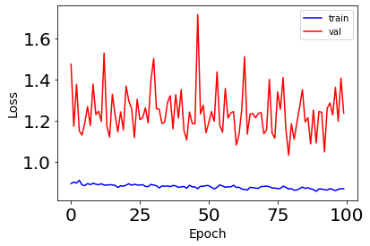

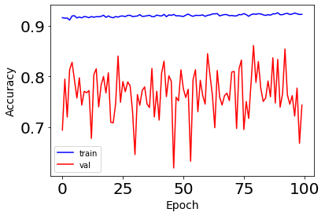

```python
# Plot the loss function
fig, ax = plt.subplots(1, 1, figsize=(6,4)) #create subplot
ax.plot(np.sqrt(model_H.history['loss']), 'b', label='train') #plot training loss
ax.plot(np.sqrt(model_H.history['val_loss']), 'r' ,label='val')#plot validation loss
ax.set_xlabel(r'Epoch', fontsize=14)#set xlabel
ax.set_ylabel(r'Loss', fontsize=14)#set ylabel
ax.legend() #legend
ax.tick_params(labelsize=20) #set label size

# Plot the accuracy
fig, ax = plt.subplots(1, 1, figsize=(6,4))#create subplot
ax.plot(np.sqrt(model_H.history['accuracy']), 'b', label='train')#plot training accuracy
ax.plot(np.sqrt(model_H.history['val_accuracy']), 'r' ,label='val')#plot validation accuracy
ax.set_xlabel(r'Epoch', fontsize=14)#set xlabel
ax.set_ylabel(r'Accuracy', fontsize=14)#set ylabel
ax.legend()#legend
ax.tick_params(labelsize=20)#set label size
```

#### Observations

- The loss increased with large value of lambda.
- The loss of validation data is expected to drop as epochs increases, but it is not observable in above graphs.
- The loss has increased and has come up to 1.4631 and the accuracy is 0.6569 which is decreased as compared to previous iteration.
- Also, the network is overfitting as the loss of validation data is more and accuracy is also low than training data which can be observed in above graphs.
- The learning rate is also responsible for such discontinuity in the accuracy and loss of validation data.

```python
X_train_subset = X_train[0:20] #pick first 20
y_train_subset = y_train_one[0:20]#pick first 20
X_train1 = X_train_subset
y_train1 = y_train_subset
```

```python
y_train1.shape #y_train shape
```

```
(20, 10)
```

```python
lr = 0.001   #learning rate
optimizer = optimizers.Adam(lr=lr) #adam optimizer
model=build_model_regulariztion(0.) #disabled regularization
model.compile(loss='categorical_crossentropy', optimizer=optimizer,  metrics=['accuracy']) #compile
```

```python
model.fit(X_train1,y_train1 , batch_size = 500, epochs = 100) #fit
```

```
Train on 20 samples
```

```
<tensorflow.python.keras.callbacks.History at 0x1b31d77fe48>
```

### Load the original dataset with all the images and prepare the data for modelling

```python
data = h5py.File('SVHN_single_grey1.h5', 'r') #read file

X_test = data['X_test'][:] #Xtest data
X_train = data['X_train'][:]#XTrain data
X_val = data['X_val'][:]#XVal data
y_test = data['y_test'][:].flatten()#ytest data
y_train = data['y_train'][:].flatten()#ytrain data
y_val = data['y_val'][:].flatten()#yVal data

data.close()#close file

#flatten
X_test = X_test.reshape(X_test.shape[0],1024) #reshape
X_train = X_train.reshape(X_train.shape[0],1024) #reshape
X_val = X_val.reshape(X_val.shape[0],1024) #reshape

# normalize inputs
X_train = X_train/255.0 # normalize
X_test = X_test/255.0 # normalize
X_val = X_val/255.0 # normalize

#onehot encoding using keras
y_train_one = keras.utils.to_categorical(y_train) #onehot encoding
y_val_one = keras.utils.to_categorical(y_val) #onehot encoding
y_test_one = keras.utils.to_categorical(y_test) #onehot encoding

print('\033[1m''X_train Shape',X_train.shape)#print shapes
print('\033[1m''X_test Shape',X_test.shape)#print shapes
print('\033[1m''X_val Shape',X_val.shape)#print shapes

print('\033[1m''y_train Shape',y_train_one.shape)#print shapes
print('\033[1m''y_test Shape',y_test_one.shape)#print shapes
print('\033[1m''y_val Shape',y_val_one.shape)#print shapes
```

```
X_train Shape (42000, 1024)
X_test Shape (18000, 1024)
X_val Shape (60000, 1024)
y_train Shape (42000, 10)
y_test Shape (18000, 10)
y_val Shape (60000, 10)
```

### Start with a small Regularization. Keep adjusting the learning rate to check the loss. Record findings

#### A model function to create model with regularization as parameter

```python
def build_model_regulariztion(lam):
    model = Sequential()#sequential network
    model.add(Dense(1024, input_shape=(1024,),kernel_initializer= 'he_normal',kernel_regularizer=l2(lam)))#dense layer
    model.add(BatchNormalization())#batch normalization
    model.add(LeakyReLU(alpha=0.1))#leaky relu
    model.add(Dropout(0.1))#dropout


    model.add(Dense(512,kernel_initializer= 'he_normal',kernel_regularizer=l2(lam)))#dense layer
    model.add(BatchNormalization())#batch normalization
    model.add(LeakyReLU(alpha=0.3))#leaky relu
    model.add(Dropout(0.1))#dropout


    model.add(Dense(256,kernel_initializer='he_normal',kernel_regularizer=l2(lam)))#dense layer
    model.add(BatchNormalization())#batch normalization
    model.add(LeakyReLU(alpha=0.3))#leaky relu
    model.add(Dropout(0.1))#dropout


    model.add(Dense(128,kernel_initializer='he_normal',kernel_regularizer=l2(lam)))#dense layer
    model.add(BatchNormalization())#batch normalization
    model.add(LeakyReLU(alpha=0.1))#leaky relu
    model.add(Dropout(0.3))#dropout

    model.add(Dense(64,kernel_initializer='he_normal',kernel_regularizer=l2(lam)))#dense layer
    model.add(BatchNormalization())#batch normalization
    model.add(LeakyReLU(alpha=0.3))#leaky relu
    model.add(Dropout(0.1))#dropout

    model.add(Dense(32,kernel_initializer='he_normal',kernel_regularizer=l2(lam)))#dense layer
    model.add(BatchNormalization())#batch normalization
    model.add(LeakyReLU(alpha=0.1))#leaky relu
    model.add(Dropout(0.3))#dropout


    model.add(Dense(10, activation='softmax'))   #dense layer
    return model
```

##### A model with 1e-7 learning rate and 1e-7 lambda value

```python
lr = 1e-7   #learning rate
optimizer = optimizers.Adam(lr=lr) #adam optimizer
model=build_model_regulariztion(1e-7) #model with disabled regularization
model.compile(loss='categorical_crossentropy', optimizer=optimizer,  metrics=['accuracy'],verbose=0) #compile model
model.fit(X_train,y_train_one , batch_size = 500, epochs = 100, validation_data=(X_val,y_val_one),verbose=0) #fit model on train and validation data
```

```
<tensorflow.python.keras.callbacks.History at 0x1b19552f608>
```

```python
results = model.evaluate(X_test, y_test_one,verbose=2) #evaluate
```

```
18000/1 - 2s - loss: 2.3642 - accuracy: 0.1322
```

- The Loss has increased to 2.3642 and the accuracy is too low, let's try increasing the learning rate ##### A model with 0.00001 learning rate and 1e-9 lambda value

```python
lr = 0.00001   #learning rate
optimizer = optimizers.Adam(lr=lr) #adam optimizer
model=build_model_regulariztion(1e-9) #model with disabled regularization
model.compile(loss='categorical_crossentropy', optimizer=optimizer,  metrics=['accuracy']) #compile model
model.fit(X_train,y_train_one , batch_size = 500, epochs = 100, validation_data=(X_val,y_val_one),verbose=0) #fit model on train and validation data
```

```
<tensorflow.python.keras.callbacks.History at 0x1b332d3bf88>
```

```python
results = model.evaluate(X_test, y_test_one,verbose=2) #evaluate
```

```
18000/1 - 2s - loss: 0.7073 - accuracy: 0.7798
```

- The Loss has decreased to 0.7073 and the accuracy has increased 0.7798.
- let's try some more learning rates ##### A model with 0.0001 learning rate and 1e-7 lambda value

```python
lr = 0.0001   #learning rate
optimizer = optimizers.Adam(lr=lr) #adam optimizer
model=build_model_regulariztion(1e-7) #model with disabled regularization
model.compile(loss='categorical_crossentropy', optimizer=optimizer,  metrics=['accuracy']) #compile model
model.fit(X_train,y_train_one , batch_size = 500, epochs = 100, validation_data=(X_val,y_val_one),verbose=0) #fit model on train and validation data
```

```python
results = model.evaluate(X_test, y_test_one,verbose=2) #evaluate
```

```
18000/1 - 2s - loss: 0.5844 - accuracy: 0.7929
```

- The Loss has decreased to 0.5844 and the accuracy has increased 0.7929.
- Higher learning rate has resulted in increased accuracy and low loss
- let's try some more learning rates ##### A model with 0.001 learning rate and 1e-9 lambda value

```python
lr = 0.001   #learning rate
optimizer = optimizers.Adam(lr=lr) #adam optimizer
model=build_model_regulariztion(1e-9) #model with disabled regularization
model.compile(loss='categorical_crossentropy', optimizer=optimizer,  metrics=['accuracy']) #compile model
model.fit(X_train,y_train_one , batch_size = 500, epochs = 100, validation_data=(X_val,y_val_one),verbose=0) #fit model on train and validation data
```

```
<tensorflow.python.keras.callbacks.History at 0x1b33dd88ec8>
```

```python
results = model.evaluate(X_test, y_test_one,verbose=2) #evaluate
```

```
18000/1 - 2s - loss: 0.5787 - accuracy: 0.7778
```

- The Loss has decreased to 0.5787 and the accuracy has decreased 0.7778.
- Probably the learning rate has become higher, let's confirm this in next iteration.
- let's try some more learning rates ##### A model with 0.01 learning rate and 1e-9 lambda value

```python
lr = 0.01   #learning rate
optimizer = optimizers.Adam(lr=lr) #adam optimizer
model=build_model_regulariztion(1e-9) #model with disabled regularization
model.compile(loss='categorical_crossentropy', optimizer=optimizer,  metrics=['accuracy']) #compile model
model.fit(X_train,y_train_one , batch_size = 500, epochs = 100, validation_data=(X_val,y_val_one),verbose=0) #fit model on train and validation data
```

```
<tensorflow.python.keras.callbacks.History at 0x1b34369fa88>
```

```python
results = model.evaluate(X_test, y_test_one,verbose=2) #evaluate
```

```
18000/1 - 2s - loss: 0.8621 - accuracy: 0.7848
```

```python
lr = 0.1   #learning rate
optimizer = optimizers.Adam(lr=lr) #adam optimizer
model=build_model_regulariztion(1e-9) #model with disabled regularization
model.compile(loss='categorical_crossentropy', optimizer=optimizer,  metrics=['accuracy']) #compile model
model.fit(X_train,y_train_one , batch_size = 500, epochs = 100, validation_data=(X_val,y_val_one),verbose=0) #fit model on train and validation data
```

```
<tensorflow.python.keras.callbacks.History at 0x1b3490c3388>
```

```python
results = model.evaluate(X_test, y_test_one,verbose=2) #evaluate
```

```
18000/1 - 2s - loss: 1.4782 - accuracy: 0.6891
```

- The Loss has again increased to 1.4782 and the accuracy has decreased to 0.6891.
- The learning rate range should be in 0.01 to 0.00001
- Let's try to optimize hyperparameters

## Perform Hyperparameter Optimization

### RandomSearchCV for hyperparameter optimization

#### Tuning of dropout_rate, optimizer, init_mode, activation and lambda

```python
def create_model(dropout_rate,optimizer,init_mode,activation,lam):
    model = Sequential()#sequential network

    model.add(Dense(1024, input_shape=(1024,),kernel_initializer= init_mode,activation=LeakyReLU(),kernel_regularizer=l2(lam)))#dense layer
    model.add(BatchNormalization())#batch normalization
    model.add(Dropout(dropout_rate))#dropout


    model.add(Dense(512,kernel_initializer= init_mode,activation=activation,kernel_regularizer=l2(lam)))#dense layer
    model.add(BatchNormalization())#batch normalization
    model.add(Dropout(dropout_rate))#dropout


    model.add(Dense(256,kernel_initializer=init_mode,activation=activation,kernel_regularizer=l2(lam)))#dense layer
    model.add(BatchNormalization())#batch normalization
    model.add(Dropout(dropout_rate))#dropout


    model.add(Dense(128,kernel_initializer=init_mode,activation=activation,kernel_regularizer=l2(lam)))#dense layer
    model.add(BatchNormalization())#batch normalization
    model.add(Dropout(dropout_rate))#dropout

    model.add(Dense(64,kernel_initializer=init_mode,activation=activation,kernel_regularizer=l2(lam)))#dense layer
    model.add(BatchNormalization())#batch normalization
    model.add(Dropout(dropout_rate))#dropout

    model.add(Dense(32,kernel_initializer=init_mode,activation=activation,kernel_regularizer=l2(lam)))#dense layer
    model.add(BatchNormalization())#batch normalization
    model.add(Dropout(dropout_rate))#dropout


    model.add(Dense(10, activation='softmax')) #dense layer


    model.compile(loss='categorical_crossentropy', optimizer=optimizer,  metrics=['acc']) #compile model with accuracy metrics
    return model #return model
```

- Only LeakyReLU is kept in activation because it has outperformed all other activations in the trial runs before finalizing the project and to reduce the execution time now.

```python
seed = 1
np.random.seed(seed) #random seed for reproducibility


network = KerasClassifier(build_fn=create_model, verbose=1)# create the sklearn model for the network
optimizer = ['SGD', 'Adam'] #optimizers
batches = [500,800] #batches
epochs = [100,150] #epochs
init_mode = [ 'lecun_uniform','glorot_uniform','he_normal','he_uniform']#initializers
dropout_rate = [0.0, 0.1, 0.2, 0.3, 0.4 ] #Dropout
activation= [LeakyReLU()]#Activation
lam=[0.,1e-7,1e-8,1e-6]#Lambda regularization parameter
verbose=[0]

param_grid = dict(optimizer=optimizer,epochs=epochs, batch_size=batches,init_mode=init_mode,
                  dropout_rate=dropout_rate,activation=activation,lam=lam,verbose=verbose)#param grid

grid = RandomizedSearchCV(network, param_grid, random_state=1) #cross validate randomized

grid_result = grid.fit(X_train, y_train_one) #fit
```

```python
### print results
print(f'Best Accuracy for {grid_result.best_score_} using {grid_result.best_params_}') #best parameters
means = grid_result.cv_results_['mean_test_score'] #mean scores
stds = grid_result.cv_results_['std_test_score'] #standard test scores
params = grid_result.cv_results_['params'] #parameters
for mean, stdev, param in zip(means, stds, params): #print all values
    print(f' mean={mean:.4}, std={stdev:.4} using {param}')
```

```
Best Accuracy for 0.8219047586123148 using {'verbose': 0, 'optimizer': 'Adam', 'lam': 0.0, 'init_mode': 'lecun_uniform', 'epochs': 150, 'dropout_rate': 0.4, 'batch_size': 500, 'activation': <tensorflow.python.keras.layers.advanced_activations.LeakyReLU object at 0x000001B34E315148>}
 mean=0.7961, std=0.006259 using {'verbose': 0, 'optimizer': 'SGD', 'lam': 1e-08, 'init_mode': 'lecun_uniform', 'epochs': 100, 'dropout_rate': 0.2, 'batch_size': 500, 'activation': <tensorflow.python.keras.layers.advanced_activations.LeakyReLU object at 0x000001B34E315148>}
 mean=0.5582, std=0.009629 using {'verbose': 0, 'optimizer': 'SGD', 'lam': 1e-06, 'init_mode': 'glorot_uniform', 'epochs': 150, 'dropout_rate': 0.4, 'batch_size': 800, 'activation': <tensorflow.python.keras.layers.advanced_activations.LeakyReLU object at 0x000001B34E315148>}
 mean=0.8085, std=0.004431 using {'verbose': 0, 'optimizer': 'Adam', 'lam': 1e-08, 'init_mode': 'glorot_uniform', 'epochs': 100, 'dropout_rate': 0.3, 'batch_size': 800, 'activation': <tensorflow.python.keras.layers.advanced_activations.LeakyReLU object at 0x000001B34E315148>}
 mean=0.8219, std=0.004755 using {'verbose': 0, 'optimizer': 'Adam', 'lam': 0.0, 'init_mode': 'lecun_uniform', 'epochs': 150, 'dropout_rate': 0.4, 'batch_size': 500, 'activation': <tensorflow.python.keras.layers.advanced_activations.LeakyReLU object at 0x000001B34E315148>}
 mean=0.8057, std=0.003327 using {'verbose': 0, 'optimizer': 'SGD', 'lam': 1e-07, 'init_mode': 'he_normal', 'epochs': 100, 'dropout_rate': 0.1, 'batch_size': 500, 'activation': <tensorflow.python.keras.layers.advanced_activations.LeakyReLU object at 0x000001B34E315148>}
 mean=0.7896, std=0.0003883 using {'verbose': 0, 'optimizer': 'SGD', 'lam': 1e-08, 'init_mode': 'he_normal', 'epochs': 100, 'dropout_rate': 0.1, 'batch_size': 800, 'activation': <tensorflow.python.keras.layers.advanced_activations.LeakyReLU object at 0x000001B34E315148>}
 mean=0.8147, std=0.003352 using {'verbose': 0, 'optimizer': 'Adam', 'lam': 0.0, 'init_mode': 'lecun_uniform', 'epochs': 100, 'dropout_rate': 0.2, 'batch_size': 800, 'activation': <tensorflow.python.keras.layers.advanced_activations.LeakyReLU object at 0x000001B34E315148>}
 mean=0.8215, std=0.00485 using {'verbose': 0, 'optimizer': 'Adam', 'lam': 1e-06, 'init_mode': 'he_normal', 'epochs': 150, 'dropout_rate': 0.4, 'batch_size': 800, 'activation': <tensorflow.python.keras.layers.advanced_activations.LeakyReLU object at 0x000001B34E315148>}
 mean=0.4524, std=0.01356 using {'verbose': 0, 'optimizer': 'SGD', 'lam': 1e-07, 'init_mode': 'he_normal', 'epochs': 150, 'dropout_rate': 0.4, 'batch_size': 800, 'activation': <tensorflow.python.keras.layers.advanced_activations.LeakyReLU object at 0x000001B34E315148>}
 mean=0.7582, std=0.01177 using {'verbose': 0, 'optimizer': 'SGD', 'lam': 1e-08, 'init_mode': 'he_uniform', 'epochs': 150, 'dropout_rate': 0.0, 'batch_size': 800, 'activation': <tensorflow.python.keras.layers.advanced_activations.LeakyReLU object at 0x000001B34E315148>}
```

##### Results of RandomizedSearchCV

```python
batch1=grid_result.best_params_['batch_size']#best batch size
epochs1=grid_result.best_params_['epochs']#best epochs
init1=grid_result.best_params_['init_mode']#best initialization mode
dropout_rate1=grid_result.best_params_['dropout_rate']#
#neurons1=grid_result.best_params_['neurons']
activation1=grid_result.best_params_['activation']
lam1=grid_result.best_params_['lam']
optimizer1=grid_result.best_params_['optimizer']

#printing all above values
print('Best batch size derived from randomsearch:',batch1)
print('Best epochs size derived from randomsearch:',epochs1)
print('Best initializer derived from randomsearch:',init1)
print('Best dropout_rate derived from randomsearch:',dropout_rate1)
#print('Best neurons size derived from gridsearch:',neurons1)
print('Best activation derived from randomsearch:',activation1)
print('Best lamda derived from randomsearch:',lam1)
print('Best optimizer derived from randomsearch:',optimizer1)
```

```
Best batch size derived from randomsearch: 500
Best epochs size derived from randomsearch: 150
Best initializer derived from randomsearch: lecun_uniform
Best dropout_rate derived from randomsearch: 0.4
Best activation derived from randomsearch: <tensorflow.python.keras.layers.advanced_activations.LeakyReLU object at 0x000001B34E315148>
Best lamda derived from randomsearch: 0.0
Best optimizer derived from randomsearch: Adam
```

##### Creating model using hyperparameters derived from RandomSearchCV

```python
model=create_model(dropout_rate=dropout_rate1,init_mode=init1,activation=activation1,lam=lam1,optimizer=optimizer1)
```

```python
model.fit(X_train,y_train_one , batch_size = batch1, epochs = epochs1, validation_data=(X_val,y_val_one),verbose=0)
#fit with callback
```

```
<tensorflow.python.keras.callbacks.History at 0x1b36308b4c8>
```

```python
results = model.evaluate(X_test, y_test_one,verbose=2) #evaluate
```

```
18000/1 - 2s - loss: 0.3612 - acc: 0.8481
```

```python
model_H=model.fit(X_train,y_train_one , batch_size = batch1 , epochs = epochs1, validation_data=(X_val,y_val_one),verbose=0)
#create history object
```

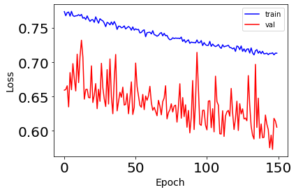

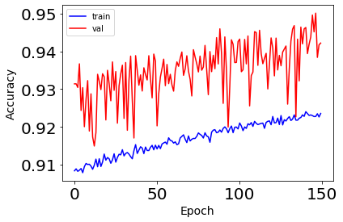

```python
# Plot the loss function
fig, ax = plt.subplots(1, 1, figsize=(6,4)) #create subplot
ax.plot(np.sqrt(model_H.history['loss']), 'b', label='train') #plot training loss
ax.plot(np.sqrt(model_H.history['val_loss']), 'r' ,label='val')#plot validation loss
ax.set_xlabel(r'Epoch', fontsize=14)#set xlabel
ax.set_ylabel(r'Loss', fontsize=14)#set ylabel
ax.legend() #legend
ax.tick_params(labelsize=20) #set label size

# Plot the accuracy
fig, ax = plt.subplots(1, 1, figsize=(6,4))#create subplot
ax.plot(np.sqrt(model_H.history['acc']), 'b', label='train')#plot training accuracy
ax.plot(np.sqrt(model_H.history['val_acc']), 'r' ,label='val')#plot validation accuracy
ax.set_xlabel(r'Epoch', fontsize=14)#set xlabel
ax.set_ylabel(r'Accuracy', fontsize=14)#set ylabel
ax.legend()#legend
ax.tick_params(labelsize=20)#set label size
```

##### Observations:

- The loss is 0.3612 and accuracy is 0.8481 using Random Search.
- The parameters are randomsearched and as RandomizedSearchCV does not guarantee the best possible hyperparameters.
- Also in the above graphs, the fluctuation in Accuracy and loss can be observed.
- Using tuning methods to smoothen the learning rate will help in reducing the fluctuatation.
- Let's try tuning the learning rate on the basic model using Learning Rate Scheduler.

### Tuning of Learning Rate

#### Drop based Learning rate scheduler

- This scheduler will help in automatically adjusting learning rate using a drop function.
- The function is designed to modify learning rate after 10 epochs.
- Initial learning rate is 0.1 which will be reduced by 0.5 after 10 epochs.

```python
initial_lrate = 0.1 #initial learning rate
drop = 0.5 #drop size
epochs_drop = 10.0 #drop after 10 epochs

def scheduler(epoch):    #define function
    lrate = initial_lrate * math.pow(drop, math.floor((1+epoch)/epochs_drop)) #drop function
    return lrate #return

callback = tf.keras.callbacks.LearningRateScheduler(scheduler) #keras callback object
```

```python
def build_model_regulariztion(lam):#network function
    model = Sequential()#sequential network
    model.add(Dense(1024, input_shape=(1024,),kernel_regularizer=l2(lam)))#dense layer
    model.add(BatchNormalization())#batch normalization
    model.add(LeakyReLU(alpha=0.1))#leaky relu
    model.add(Dropout(0.1))#dropout


    model.add(Dense(512,kernel_initializer= 'he_normal',kernel_regularizer=l2(lam)))#dense layer
    model.add(BatchNormalization())#batch normalization
    model.add(LeakyReLU(alpha=0.3))#leaky relu
    model.add(Dropout(0.1))#dropout


    model.add(Dense(256,kernel_initializer='he_normal',kernel_regularizer=l2(lam)))#dense layer
    model.add(BatchNormalization())#batch normalization
    model.add(LeakyReLU(alpha=0.3))#leaky relu
    model.add(Dropout(0.1))#dropout


    model.add(Dense(128,kernel_initializer='he_normal',kernel_regularizer=l2(lam)))#dense layer
    model.add(BatchNormalization())#batch normalization
    model.add(LeakyReLU(alpha=0.1))#leaky relu
    model.add(Dropout(0.3))#dropout

    model.add(Dense(64,kernel_initializer='he_normal',kernel_regularizer=l2(lam)))#dense layer
    model.add(BatchNormalization())#batch normalization
    model.add(LeakyReLU(alpha=0.3))#leaky relu
    model.add(Dropout(0.1))#dropout

    model.add(Dense(32,kernel_initializer='he_normal',kernel_regularizer=l2(lam)))#dense layer
    model.add(BatchNormalization())#batch normalization
    model.add(LeakyReLU(alpha=0.1))#leaky relu
    model.add(Dropout(0.3))#dropout


    model.add(Dense(10, activation='softmax'))   #dense layer
    return model
```

- Create a model using above function with regularizarion parameter as 1e-7 and SGD optimizer with 0.8 momentum
- The learning rate will be implemented in a way where in the beginning the learning rate will be higher but it will be reduced as epochs increases which is in theory.
- The callback is used to use keras callback history object

```python
model=build_model_regulariztion(1e-7) #build model
sgd = optimizers.SGD(lr=0.0, momentum=0.8) #SGD optimizer
model.compile(loss='categorical_crossentropy', optimizer=sgd,  metrics=['accuracy']) #compile model with accuracy metrics
                                                                                #and 'categorical_crossentropy' as loss measure
```

```python
model.summary()
```

```
Model: "sequential_42"
_________________________________________________________________
Layer (type)                 Output Shape              Param #
=================================================================
dense_294 (Dense)            (None, 1024)              1049600
_________________________________________________________________
batch_normalization_252 (Bat (None, 1024)              4096
_________________________________________________________________
leaky_re_lu_93 (LeakyReLU)   (None, 1024)              0
_________________________________________________________________
dropout_249 (Dropout)        (None, 1024)              0
_________________________________________________________________
dense_295 (Dense)            (None, 512)               524800
_________________________________________________________________
batch_normalization_253 (Bat (None, 512)               2048
_________________________________________________________________
leaky_re_lu_94 (LeakyReLU)   (None, 512)               0
_________________________________________________________________
dropout_250 (Dropout)        (None, 512)               0
_________________________________________________________________
dense_296 (Dense)            (None, 256)               131328
_________________________________________________________________
batch_normalization_254 (Bat (None, 256)               1024
_________________________________________________________________
leaky_re_lu_95 (LeakyReLU)   (None, 256)               0
_________________________________________________________________
dropout_251 (Dropout)        (None, 256)               0
_________________________________________________________________
dense_297 (Dense)            (None, 128)               32896
_________________________________________________________________
batch_normalization_255 (Bat (None, 128)               512
_________________________________________________________________
leaky_re_lu_96 (LeakyReLU)   (None, 128)               0
_________________________________________________________________
dropout_252 (Dropout)        (None, 128)               0
_________________________________________________________________
dense_298 (Dense)            (None, 64)                8256
_________________________________________________________________
batch_normalization_256 (Bat (None, 64)                256
_________________________________________________________________
leaky_re_lu_97 (LeakyReLU)   (None, 64)                0
_________________________________________________________________
dropout_253 (Dropout)        (None, 64)                0
_________________________________________________________________
dense_299 (Dense)            (None, 32)                2080
_________________________________________________________________
batch_normalization_257 (Bat (None, 32)                128
_________________________________________________________________
leaky_re_lu_98 (LeakyReLU)   (None, 32)                0
_________________________________________________________________
dropout_254 (Dropout)        (None, 32)                0
_________________________________________________________________
dense_300 (Dense)            (None, 10)                330
=================================================================
Total params: 1,757,354
Trainable params: 1,753,322
Non-trainable params: 4,032
_________________________________________________________________
```

- The network has 1,757,354 total parameters from which 4,032 are non trainable and 1,753,322 are trainable.

```python
model.fit(X_train,y_train_one , batch_size = 500, epochs = 100, validation_data=(X_val,y_val_one),callbacks=[callback],verbose=2)
#fit with callback
```

```
Train on 42000 samples, validate on 60000 samples
42000/42000 - 3s - loss: 1.9396 - accuracy: 0.3035 - val_loss: 1.8809 - val_accuracy: 0.3087
42000/42000 - 1s - loss: 1.3602 - accuracy: 0.5369 - val_loss: 1.6916 - val_accuracy: 0.4406
42000/42000 - 1s - loss: 1.1363 - accuracy: 0.6293 - val_loss: 1.6905 - val_accuracy: 0.4584
42000/42000 - 1s - loss: 1.0162 - accuracy: 0.6780 - val_loss: 1.0937 - val_accuracy: 0.6386
42000/42000 - 1s - loss: 0.9085 - accuracy: 0.7133 - val_loss: 1.9191 - val_accuracy: 0.4625
42000/42000 - 1s - loss: 0.8495 - accuracy: 0.7377 - val_loss: 1.2886 - val_accuracy: 0.5648
42000/42000 - 1s - loss: 0.7964 - accuracy: 0.7555 - val_loss: 1.2676 - val_accuracy: 0.5792
42000/42000 - 1s - loss: 0.7664 - accuracy: 0.7641 - val_loss: 1.3039 - val_accuracy: 0.5710
42000/42000 - 1s - loss: 0.7161 - accuracy: 0.7818 - val_loss: 1.0342 - val_accuracy: 0.6620
42000/42000 - 1s - loss: 0.6346 - accuracy: 0.8065 - val_loss: 0.9769 - val_accuracy: 0.6994
42000/42000 - 1s - loss: 0.6110 - accuracy: 0.8136 - val_loss: 0.8104 - val_accuracy: 0.7309
42000/42000 - 1s - loss: 0.6045 - accuracy: 0.8157 - val_loss: 0.8972 - val_accuracy: 0.6966
42000/42000 - 1s - loss: 0.5914 - accuracy: 0.8200 - val_loss: 0.6881 - val_accuracy: 0.7764
42000/42000 - 1s - loss: 0.5756 - accuracy: 0.8256 - val_loss: 0.7554 - val_accuracy: 0.7580
42000/42000 - 1s - loss: 0.5575 - accuracy: 0.8324 - val_loss: 0.7861 - val_accuracy: 0.7387
42000/42000 - 1s - loss: 0.5481 - accuracy: 0.8343 - val_loss: 0.8696 - val_accuracy: 0.7090
42000/42000 - 1s - loss: 0.5317 - accuracy: 0.8395 - val_loss: 0.6550 - val_accuracy: 0.7939
42000/42000 - 1s - loss: 0.5261 - accuracy: 0.8399 - val_loss: 0.6522 - val_accuracy: 0.7982
42000/42000 - 1s - loss: 0.5193 - accuracy: 0.8437 - val_loss: 0.6727 - val_accuracy: 0.7805
42000/42000 - 1s - loss: 0.4738 - accuracy: 0.8581 - val_loss: 0.5090 - val_accuracy: 0.8397
42000/42000 - 1s - loss: 0.4591 - accuracy: 0.8634 - val_loss: 0.6222 - val_accuracy: 0.7961
42000/42000 - 1s - loss: 0.4578 - accuracy: 0.8644 - val_loss: 0.5411 - val_accuracy: 0.8255
42000/42000 - 1s - loss: 0.4472 - accuracy: 0.8666 - val_loss: 0.5284 - val_accuracy: 0.8343
42000/42000 - 1s - loss: 0.4465 - accuracy: 0.8660 - val_loss: 0.4513 - val_accuracy: 0.8621
42000/42000 - 1s - loss: 0.4377 - accuracy: 0.8686 - val_loss: 0.6136 - val_accuracy: 0.7969
42000/42000 - 1s - loss: 0.4306 - accuracy: 0.8705 - val_loss: 0.4879 - val_accuracy: 0.8457
42000/42000 - 1s - loss: 0.4246 - accuracy: 0.8730 - val_loss: 0.5981 - val_accuracy: 0.8114
42000/42000 - 1s - loss: 0.4294 - accuracy: 0.8713 - val_loss: 0.4760 - val_accuracy: 0.8490
42000/42000 - 1s - loss: 0.4191 - accuracy: 0.8736 - val_loss: 0.4513 - val_accuracy: 0.8660
42000/42000 - 1s - loss: 0.3905 - accuracy: 0.8838 - val_loss: 0.3778 - val_accuracy: 0.8870
42000/42000 - 1s - loss: 0.3848 - accuracy: 0.8856 - val_loss: 0.4120 - val_accuracy: 0.8753
42000/42000 - 1s - loss: 0.3890 - accuracy: 0.8837 - val_loss: 0.4776 - val_accuracy: 0.8515
42000/42000 - 1s - loss: 0.3755 - accuracy: 0.8890 - val_loss: 0.4897 - val_accuracy: 0.8510
42000/42000 - 1s - loss: 0.3747 - accuracy: 0.8874 - val_loss: 0.6031 - val_accuracy: 0.8349
42000/42000 - 1s - loss: 0.3710 - accuracy: 0.8905 - val_loss: 0.4064 - val_accuracy: 0.8750
42000/42000 - 1s - loss: 0.3671 - accuracy: 0.8927 - val_loss: 0.4148 - val_accuracy: 0.8731
42000/42000 - 1s - loss: 0.3656 - accuracy: 0.8907 - val_loss: 0.3865 - val_accuracy: 0.8808
42000/42000 - 1s - loss: 0.3699 - accuracy: 0.8901 - val_loss: 0.4358 - val_accuracy: 0.8619
42000/42000 - 1s - loss: 0.3607 - accuracy: 0.8918 - val_loss: 0.3323 - val_accuracy: 0.9013
```

[output cut: 46 more lines]

```
42000/42000 - 1s - loss: 0.2975 - accuracy: 0.9124 - val_loss: 0.2489 - val_accuracy: 0.9303
42000/42000 - 1s - loss: 0.3022 - accuracy: 0.9101 - val_loss: 0.2497 - val_accuracy: 0.9296
42000/42000 - 1s - loss: 0.3005 - accuracy: 0.9105 - val_loss: 0.2489 - val_accuracy: 0.9301
42000/42000 - 1s - loss: 0.3027 - accuracy: 0.9125 - val_loss: 0.2485 - val_accuracy: 0.9308
42000/42000 - 1s - loss: 0.2977 - accuracy: 0.9126 - val_loss: 0.2481 - val_accuracy: 0.9303
42000/42000 - 1s - loss: 0.3017 - accuracy: 0.9095 - val_loss: 0.2480 - val_accuracy: 0.9305
42000/42000 - 1s - loss: 0.3000 - accuracy: 0.9115 - val_loss: 0.2471 - val_accuracy: 0.9304
42000/42000 - 1s - loss: 0.2997 - accuracy: 0.9124 - val_loss: 0.2475 - val_accuracy: 0.9304
42000/42000 - 1s - loss: 0.3006 - accuracy: 0.9110 - val_loss: 0.2467 - val_accuracy: 0.9308
42000/42000 - 1s - loss: 0.2984 - accuracy: 0.9114 - val_loss: 0.2467 - val_accuracy: 0.9310
42000/42000 - 1s - loss: 0.2970 - accuracy: 0.9119 - val_loss: 0.2478 - val_accuracy: 0.9306
42000/42000 - 1s - loss: 0.3063 - accuracy: 0.9102 - val_loss: 0.2469 - val_accuracy: 0.9308
42000/42000 - 1s - loss: 0.3000 - accuracy: 0.9102 - val_loss: 0.2475 - val_accuracy: 0.9305
42000/42000 - 1s - loss: 0.3015 - accuracy: 0.9101 - val_loss: 0.2468 - val_accuracy: 0.9308
42000/42000 - 1s - loss: 0.2979 - accuracy: 0.9111 - val_loss: 0.2462 - val_accuracy: 0.9313
```

```
<tensorflow.python.keras.callbacks.History at 0x1b36dd45ac8>
```

```python
results = model.evaluate(X_test, y_test_one,verbose=2) #evaluate
```

```
18000/1 - 2s - loss: 0.2469 - accuracy: 0.8761
```

```python
model_H=model.fit(X_train,y_train_one , batch_size = 500, epochs = 100, validation_data=(X_val,y_val_one),callbacks=[callback],verbose=0)
#create history object
```

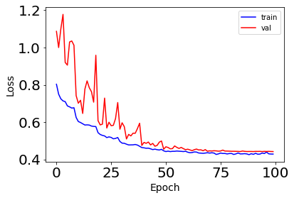

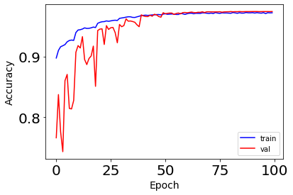

```python
# Plot the loss function
fig, ax = plt.subplots(1, 1, figsize=(6,4)) #create subplot
ax.plot(np.sqrt(model_H.history['loss']), 'b', label='train') #plot training loss
ax.plot(np.sqrt(model_H.history['val_loss']), 'r' ,label='val')#plot validation loss
ax.set_xlabel(r'Epoch', fontsize=14)#set xlabel
ax.set_ylabel(r'Loss', fontsize=14)#set ylabel
ax.legend() #legend
ax.tick_params(labelsize=20) #set label size

# Plot the accuracy
fig, ax = plt.subplots(1, 1, figsize=(6,4))#create subplot
ax.plot(np.sqrt(model_H.history['accuracy']), 'b', label='train')#plot training accuracy
ax.plot(np.sqrt(model_H.history['val_accuracy']), 'r' ,label='val')#plot validation accuracy
ax.set_xlabel(r'Epoch', fontsize=14)#set xlabel
ax.set_ylabel(r'Accuracy', fontsize=14)#set ylabel
ax.legend()#legend
ax.tick_params(labelsize=20)#set label size
```

#### Observations

- The loss of validation data is expected to drop as epochs increases which is observable in above graphs indicating reduction of loss and increased accuracy as compared to previous iterations.
- The loss has decreased has come down to 0.2469 and the accuracy has reached to 0.8761 which is significant increase as compared to all previous iterations.
- In the above graph, it can be observed that the accuracy of validation data is almost equal to training data in later epochs and the loss is minimum indicating low overfitting without compromising the models performance.
- The model with tuned learning rate produced best results.

## Predictions and evaluation

- The predictions and evaluation is performed on the network with tuned learning rate.
- Confusion matrix and precision, recall, f1-score are considered while evaluating the networks performance.

```python
y_pred = model.predict_classes(X_test, batch_size=200, verbose=0)
print(confusion_matrix(y_test, y_pred))
print(classification_report(y_test, y_pred))
```

```
[[1663   21    7   13   14    8   20   16   14   38]
 [  21 1627   18   26   44    9   11   37   25   10]
 [  16   16 1620   35   18    9    2   34   25   28]
 [   8   23   32 1441    9   94   15   26   51   20]
 [  18   34   14   20 1650    8   21   11   14   22]
 [  10   13    7   65    9 1539   56    9   31   29]
 [  42   10    8   12   30   61 1582   11   64   12]
 [  15   53   31   23   15    6    9 1638    7   11]
 [  23   30   13   43    9   16   74    8 1550   46]
 [  56   20   25   32   11   38    3   18   36 1565]]
              precision    recall  f1-score   support

           0       0.89      0.92      0.90      1814
           1       0.88      0.89      0.89      1828
           2       0.91      0.90      0.91      1803
           3       0.84      0.84      0.84      1719
           4       0.91      0.91      0.91      1812
           5       0.86      0.87      0.87      1768
           6       0.88      0.86      0.87      1832
           7       0.91      0.91      0.91      1808
           8       0.85      0.86      0.85      1812
           9       0.88      0.87      0.87      1804

    accuracy                           0.88     18000
   macro avg       0.88      0.88      0.88     18000
weighted avg       0.88      0.88      0.88     18000
```

```python
print('Accuracy Model: '+ str(model.evaluate(X_test,y_test_one,verbose=2)[1]))
print('Recall_score: ' + str(recall_score(y_test,y_pred,average='micro')))
print('Precision_score: ' + str(precision_score(y_test, y_pred,average='micro')))
print('F-score: ' + str(f1_score(y_test,y_pred,average='micro')))
```

```
18000/1 - 1s - loss: 0.2653 - accuracy: 0.8819
Accuracy Model: 0.8819444
Recall_score: 0.8819444444444444
Precision_score: 0.8819444444444444
F-score: 0.8819444444444444
```

### Predictions from network

- All predictions are selected at random.

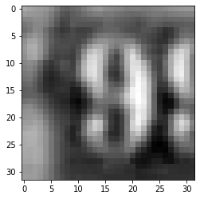

```python
plt.imshow(X_test[5].reshape(32,32),cmap='gray')
```

```python
model.predict_classes(X_test)[5]
```

```
9
```

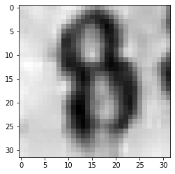

```python
plt.imshow(X_test[10].reshape(32,32),cmap='gray')
```

```python
model.predict_classes(X_test)[10]
```

```
8
```

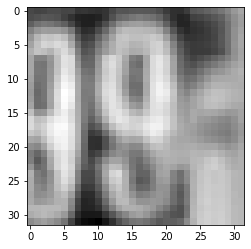

```python
#Showing the image
plt.imshow(X_test[112].reshape(32,32),cmap='gray')
```

```python
model.predict_classes(X_test)[112]
```

```
9
```

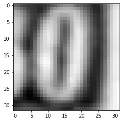

```python
#Showing the image
plt.imshow(X_test[320].reshape(32,32),cmap='gray')
```

```python
model.predict_classes(X_test)[320]
```

```
0
```

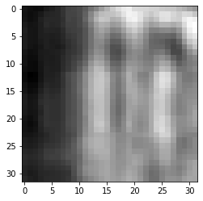

```python
#Showing the image
plt.imshow(X_test[1000].reshape(32,32),cmap='gray')
```

```python
model.predict_classes(X_test)[1000]
```

```
1
```

## Comments

- All insights, important observation have alredy been added below every step. These are some concluding comments.

### Comments on Dataset

- The dataset is of h5py type, which is herarchical file type.
- All the train, test and validation data was already present in splits, so no train_test_val split is performed.
- The Number of samples in train test and validation are unequal.
- The networks are trained on 42000 samples, validated on 60000 samples and tested on 18000 samples.

### Comments on Networks

- At first, The model without any regularization performed well than model with large lambda(Regularization) value.
- The number of hidden layers and neurons in each hidden layer are chosen at random, but for input and output layer the number of neurons depended on number of input and output classes.
- The Loss of validation and training should be almost equal in the end, which is achieved in the last network, which produced around 88% accuracy.

### Miscellaneous Comments

- GridSearchCV lead to infinite loop while training the parameters, the jupyter kernel used to disconnect after 4-5 hours.
- On google colab, GridSearchCV ran for almost 12 hours before being disconnected.
- Hyperparameters could have been more tuned with gridsearchCV or hyperas packages with a lot of time and infrastructure to execute all possible grids with parameters such as number of hidden layers, number of neurons, activations, dropout, regularization, batch size, epochs, and optimizer.
- Tuning a single parameter at a time did not produce optimum results after combining all hyperparameters in a network, the loss and accuracy exploded.
- I tried talos,hyperas and gridsearchCV for optimization, but due to lack of infrastructure, the functions were not able to tune all parameters at ones.
- RandomSearch Doesnot guarantee the best set of hyperparameters, so I had to use a default netowrk with tuned learning rate to produce higher results.
- Only LeakyReLU is used in RandomizedSearchCV because of its performance in previous iterations and to save time while finalizing the project.

###### References:

https://stats.stackexchange.com/questions/369104/what-is-a-sensible-order-for-parameter-tuning-in-neural-networks https://www.tensorflow.org/api_docs/python/tf/keras/callbacks/LearningRateScheduler https://machinelearningmastery.com/grid-search-hyperparameters-deep-learning-models-python-keras/